# Module 04 — PyPSA-RSA + South Africa Source Audit Overview

This notebook reads every audit artefact produced by `scripts/build_za_source_audits.py` and renders a presentation-ready summary.

It is read-only with respect to the model. No fleet, carrier, cost, demand, or grid override is written here.

The PyPSA-RSA reference repo is pinned at commit `89872c1ea703af3d8a3f198706d1ab7958f50a5f`. The pin matched both local HEAD and `origin/main` at module entry.

```python
from pathlib import Path
import pandas as pd

AUDIT = Path('../../../data/za_audit').resolve()
FIG   = Path('../../../doc/za_validation/figures/04_source_audits').resolve()
FIG.mkdir(parents=True, exist_ok=True)
pd.set_option('display.max_rows', 60)
pd.set_option('display.max_columns', 80)
pd.set_option('display.width', 180)
```

## 1 — Source registry and discovery sweep

```python
registry = pd.read_csv(AUDIT / 'pypsa_rsa_source_registry.csv')
print('registry rows:', len(registry))
print('port_policy distribution:')
print(registry['port_policy'].value_counts())
print()
print('owning_module distribution:')
print(registry['owning_module'].value_counts().sort_index())
registry.head(15)
```

```
registry rows: 72
port_policy distribution:
port_policy
validation_reference    36
audit_only              30
do_not_port              6
Name: count, dtype: int64

owning_module distribution:
owning_module
2      1
3      8
4      5
6      4
7      4
8     11
9     13
11     7
12     1
13    18
Name: count, dtype: int64
```

|  | source_path | tracked_or_external | hash | sheet_or_layer | row_count | port_policy | owning_module | baseline_use | expansion_use | notes |
| --- | --- | --- | --- | --- | --- | --- | --- | --- | --- | --- |
| 0 | README.md | tracked | ee1aac0bfc5a53f5c857e4340aaab0b661faee65c0b79d... | NaN | -1 | audit_only | 4 | audit_only | audit_only | PyPSA-RSA repo README at pinned commit |
| 1 | config.yaml | tracked | 5607ebb37c915d18e6023992dcc70a621a1d88bb9639bf... | NaN | -1 | validation_reference | 4 | audit_only | audit_only | PyPSA-RSA Snakemake config; reference for grid... |
| 2 | Snakefile | tracked | 5aa1ebf99ad9801fee76ffea290979ad14eade3ea105b4... | NaN | -1 | audit_only | 4 | audit_only | audit_only | PyPSA-RSA Snakefile |
| 3 | scripts/add_electricity.py | tracked | 9a51c546e7dc95be2606545ced138b3f082214e4b1fbd0... | NaN | -1 | validation_reference | 7 | validation_reference | audit_only | Cost/fuel/heat-rate transformation reference |
| 4 | scripts/build_topology.py | tracked | 84fa438d3359ba9280ce939482fed8d16da5eaccd60d7f... | NaN | -1 | validation_reference | 9 | audit_only | audit_only | Supply-region topology reference |
| 5 | scripts/base_network.py | tracked | f311415cd20f9947c67b58e983aea8f569919c5cd9063d... | NaN | -1 | validation_reference | 9 | audit_only | audit_only | Base network construction reference |
| 6 | scripts/_helpers.py | tracked | 87d1f7c7a7a145840bd08c0906d62a637afb4768268cbe... | NaN | -1 | audit_only | 4 | audit_only | audit_only | Shared helpers |
| 7 | scripts/custom_constraints.py | tracked | 736fb257fe41d1ec07074bf2438d4f5d4ec13e6d4f8d1a... | NaN | -1 | audit_only | 13 | audit_only | audit_only | Custom constraint examples (expansion handoff) |
| 8 | scripts/prepare_and_solve_network.py | tracked | 5f945522795e94bb9c74bac01c287a0a221aeadb3c76ff... | NaN | -1 | audit_only | 13 | audit_only | audit_only | Workflow constraint logic; expansion handoff c... |
| 9 | envs/environment.yaml | tracked | ef50fa3eea8c03b5907b2375aac43abc7bb84637296696... | NaN | -1 | audit_only | 4 | audit_only | audit_only | PyPSA-RSA conda env; version reference |
| 10 | data/eskom_data.csv | tracked | 86d7c7f7e4afdedcea4f81b3836610370333811d5d4239... | NaN | 50401 | validation_reference | 2 | validation_reference | audit_only | Validation reference; not first-choice 2023 input |
| 11 | data/eskom_pu_profiles.csv | tracked | f29faf9bb1cee60c91687c08bdc2fea4d730787bfca449... | NaN | 39361 | validation_reference | 3 | validation_reference | audit_only | Profile reference; consumed by Module 03 Gate B |
| 12 | data/bundle/SystemEnergy2009_22.csv | external | 2342f7147cb2be1ea9455918195472594e339f66720f82... | NaN | 100056 | validation_reference | 6 | validation_reference | audit_only | Historical system energy series |
| 13 | data/bundle/Supply area normalised power feed-... | external | 99b75ff9b16f4249f9d2d84bb3fef828156226a616b046... | Background information;Wind power profiles;Add... | 70271 | validation_reference | 3 | validation_reference | audit_only | PyPSA-RSA wind reference profiles by supply area |
| 14 | data/bundle/Supply area normalised power feed-... | external | 9ef26df47e8f9ca4d65db99b578ac374ce11684a0c3ce5... | Background information;PV profiles;Additional ... | 35225 | validation_reference | 3 | validation_reference | audit_only | PyPSA-RSA PV reference profiles by supply area |

```python
discovery = pd.read_csv(AUDIT / 'pypsa_rsa_discovery_sweep.csv')
print('discovery rows:', len(discovery))
print('classification:')
print(discovery['classification'].value_counts())
print()
print('kind:')
print(discovery['kind'].value_counts())
discovery.head(10)
```

```
discovery rows: 77
classification:
classification
covered       50
audit_only    27
Name: count, dtype: int64

kind:
kind
workbook    26
spatial     21
notebook    10
script       9
tabular      5
netcdf       4
raster       2
Name: count, dtype: int64
```

|  | rel_path | size_bytes | suffix | kind | in_min_coverage | classification |
| --- | --- | --- | --- | --- | --- | --- |
| 0 | data/bundle/renewable_profiles_updated.nc | 715101674 | .nc | netcdf | True | covered |
| 1 | networks/ME IRP 2024/base/capacity-IRP_H12_CL_... | 3872189 | .nc | netcdf | False | audit_only |
| 2 | networks/ME IRP 2024/base/capacity-IRP_REF_CI.nc | 3872189 | .nc | netcdf | False | audit_only |
| 3 | networks/ME IRP 2024/elec/capacity-IRP_H12_CL_... | 378958916 | .nc | netcdf | False | audit_only |
| 4 | pre_processing/outages/outages.ipynb | 124397 | .ipynb | notebook | False | audit_only |
| 5 | pre_processing/resource_processing/convert_exc... | 26171 | .ipynb | notebook | False | audit_only |
| 6 | pre_processing/resource_processing/plotting.ipynb | 449476 | .ipynb | notebook | False | audit_only |
| 7 | pre_processing/resource_processing/prepare_ava... | 632298 | .ipynb | notebook | False | audit_only |
| 8 | pre_processing/resource_processing/prepare_ext... | 18919 | .ipynb | notebook | False | audit_only |
| 9 | pre_processing/resource_processing/prepare_ext... | 63132 | .ipynb | notebook | False | audit_only |

## 2 — Powerplantmatching extraction

```python
ppm = pd.read_csv(AUDIT / 'powerplants_pm_za_audit.csv')
print('ppm ZA rows:', len(ppm))
if len(ppm):
    print('Fueltype distribution:')
    print(ppm['Fueltype'].value_counts())
    print()
    print('total capacity (MW) by Fueltype:')
    print(ppm.groupby('Fueltype')['Capacity'].sum().sort_values(ascending=False))
ppm.head(10)
```

```
ppm ZA rows: 276
Fueltype distribution:
Fueltype
Solar            147
Wind              52
Hard Coal         26
Hydro             18
Solid Biomass     14
Waste              6
Oil                5
Natural Gas        4
Nuclear            3
Biogas             1
Name: count, dtype: int64

total capacity (MW) by Fueltype:
Fueltype
Hard Coal        50087.429354
Solar             6620.200000
Wind              5555.400000
Hydro             3570.365091
Oil               2473.101123
Nuclear           1959.005266
Natural Gas       1306.740341
Solid Biomass      356.000000
Waste               42.590000
Biogas              19.000000
Name: Capacity, dtype: float64
```

|  | Name | Fueltype | Technology | Set | Country | Capacity | Efficiency | DateIn | DateRetrofit | DateOut | lat | lon | Duration | Volume_Mm3 | DamHeight_m | StorageCapacity_MWh | EIC | projectID | source_count | source_flags | raw_project_ids |
| --- | --- | --- | --- | --- | --- | --- | --- | --- | --- | --- | --- | --- | --- | --- | --- | --- | --- | --- | --- | --- | --- |
| 0 | Noupoort Wind Farm | Wind | Onshore | PP | South Africa | 80.0 | NaN | 2016.0 | NaN | NaN | -31.173600 | 25.016500 | NaN | NaN | NaN | NaN | {nan} | {'GWPT': {'G100000900049'}, 'GPD': {'WRI106130... | 1 | ppm | {'GWPT': {'G100000900049'}, 'GPD': {'WRI106130... |
| 1 | Kalkbult Solar Farm | Solar | PV | PP | South Africa | 75.0 | NaN | 2013.0 | NaN | NaN | -30.160700 | 24.134900 | NaN | NaN | NaN | NaN | {nan} | {'GSPT': {'G100000800194'}, 'GPD': {'WRI102604... | 1 | ppm | {'GSPT': {'G100000800194'}, 'GPD': {'WRI102604... |
| 2 | Koeberg 1 | Nuclear | Steam Turbine | PP | South Africa | 970.0 | NaN | 1984.0 | NaN | NaN | -33.674600 | 18.432100 | NaN | NaN | NaN | NaN | {nan} | {'GNPT': {'G100000500317'}, 'GPD': {'WRI100013... | 1 | ppm | {'GNPT': {'G100000500317'}, 'GPD': {'WRI100013... |
| 3 | Drakensberg | Hydro | Pumped Storage | Storage | South Africa | 1000.0 | NaN | 1981.0 | NaN | NaN | -28.566000 | 29.083400 | NaN | NaN | NaN | NaN | {nan} | {'GHPT': {'G100000603350'}, 'GPD': {'WRI100012... | 1 | ppm | {'GHPT': {'G100000603350'}, 'GPD': {'WRI100012... |
| 4 | Gariep | Hydro | Reservoir | PP | South Africa | 360.0 | NaN | 1971.0 | NaN | NaN | -30.623300 | 25.506700 | NaN | NaN | NaN | NaN | {nan} | {'GHPT': {'G100000603351'}, 'GPD': {'WRI100012... | 1 | ppm | {'GHPT': {'G100000603351'}, 'GPD': {'WRI100012... |
| 5 | Palmiet | Hydro | Pumped Storage | Storage | South Africa | 400.0 | NaN | 1988.0 | NaN | NaN | -34.198500 | 18.974600 | NaN | NaN | NaN | NaN | {nan} | {'GHPT': {'G100000603353'}, 'GPD': {'WRI100013... | 1 | ppm | {'GHPT': {'G100000603353'}, 'GPD': {'WRI100013... |
| 6 | Vanderkloof | Hydro | Reservoir | PP | South Africa | 240.0 | NaN | 1976.0 | NaN | NaN | -29.991100 | 24.731700 | NaN | NaN | NaN | NaN | {nan} | {'GHPT': {'G100000603356'}, 'GPD': {'WRI100013... | 1 | ppm | {'GHPT': {'G100000603356'}, 'GPD': {'WRI100013... |
| 7 | Acacia | Oil | Steam Turbine | PP | South Africa | 171.0 | 0.303 | 1976.0 | NaN | NaN | -33.883115 | 18.535834 | NaN | NaN | NaN | NaN | {nan, nan, nan} | {'GGPT': {'G100000411354', 'G100000411352', 'G... | 1 | ppm | {'GGPT': {'G100000411354', 'G100000411352', 'G... |
| 8 | Ankerlig | Oil | Steam Turbine | PP | South Africa | 1338.3 | NaN | 2007.0 | NaN | NaN | -33.589479 | 18.461496 | NaN | NaN | NaN | NaN | {nan, nan, nan, nan, nan, nan, nan, nan, nan} | {'GGPT': {'G100000414357', 'G100000414351', 'G... | 1 | ppm | {'GGPT': {'G100000414357', 'G100000414351', 'G... |
| 9 | Gourikwa | Oil | Steam Turbine | PP | South Africa | 740.0 | NaN | 2007.0 | NaN | NaN | -34.166755 | 21.960715 | NaN | NaN | NaN | NaN | {nan, nan, nan, nan, nan} | {'GGPT': {'G100000408557', 'G100000410885', 'G... | 1 | ppm | {'GGPT': {'G100000408557', 'G100000410885', 'G... |

## 3 — Scenario workbook inventory

```python
wb = pd.read_csv(AUDIT / 'pypsa_rsa_scenario_workbook_inventory.csv')
print('workbook sheet rows:', len(wb))
wb.groupby(['scenario_set','role'])[['n_rows','n_cols']].sum()
```

```
workbook sheet rows: 55
```

| scenario_set | role | n_rows | n_cols |
| --- | --- | --- | --- |
| Coal_Flexibilisation | annual_load | 10 | 46 |
|  | aux_stg_feed | 15 | 39 |
|  | emissions | 242 | 178 |
|  | extendable_technologies | 930 | 258 |
|  | fixed_technologies | 426 | 61 |
|  | fuel_prices | 336 | 190 |
|  | master | 930 | 99 |
|  | operational_constraints | 161 | 94 |
|  | phased_decommissioning | 328 | 41 |
|  | plant_availability | 393 | 96 |
|  | reserve_margin | 34 | 53 |
|  | transmission_expansion | 17 | 46 |
|  | weather | 19 | 37 |
| ME IRP 2024 | annual_load | 3 | 35 |
|  | carbon_constraints | 45 | 93 |
|  | extendable_technologies | 1205 | 214 |
|  | fixed_technologies | 791 | 58 |
|  | master | 49 | 24 |
|  | operational_constraints | 104 | 40 |
|  | plant_availability | 328 | 115 |
|  | reserve_margin | 34 | 42 |
|  | transmission_expansion | 17 | 36 |

## 4 — Fleet candidates with 2023-active filter

Filter:

```
Commissioning Date <= 2023
AND
(Decommissioning Date > 2023 OR Decommissioning Date IS NULL)
```

Future assets stay in the audit but with `included_2023 = false`.

```python
fixed = pd.read_csv(AUDIT / 'pypsa_rsa_fixed_technologies_2023_candidates.csv')
print('fixed_tech rows:', len(fixed))
print('included_2023:')
print(fixed['included_2023'].value_counts())
print()
print('Carrier x included_2023:')
if 'Carrier' in fixed.columns:
    print(fixed.groupby(['Carrier','included_2023']).size().unstack(fill_value=0))
fixed[['scenario_set','sheet','Power Station Name','Carrier','commissioning_year','decommissioning_year','included_2023']].head(15)
```

```
fixed_tech rows: 1211
included_2023:
included_2023
False    905
True     306
Name: count, dtype: int64

Carrier x included_2023:
included_2023     False  True
Carrier
battery_4h           24      1
bioenergy             3     12
coal                214      5
hydro                14     12
hydro_import          0      3
nuclear               7      0
ocgt_avf             12      0
ocgt_diesel          28      0
ocgt_gas              2      0
phs                   8      0
rmippp               66      0
sasol_coal           13      0
sasol_gas            14      0
solar_csp             3     18
solar_pv             32    135
solar_pv_rooftop      0     18
wind                 42    102
```

|  | scenario_set | sheet | Power Station Name | Carrier | commissioning_year | decommissioning_year | included_2023 |
| --- | --- | --- | --- | --- | --- | --- | --- |
| 0 | ME IRP 2024 | conventional | Arnot* | coal | NaN | 2027.0 | False |
| 1 | ME IRP 2024 | conventional | Arnot** | coal | NaN | 2029.0 | False |
| 2 | ME IRP 2024 | conventional | Camden* | coal | NaN | 2024.0 | False |
| 3 | ME IRP 2024 | conventional | Camden** | coal | NaN | 2025.0 | False |
| 4 | ME IRP 2024 | conventional | Duvha* | coal | NaN | 2033.0 | False |
| 5 | ME IRP 2024 | conventional | Duvha** | coal | NaN | 2034.0 | False |
| 6 | ME IRP 2024 | conventional | Grootvlei* | coal | NaN | 2026.0 | False |
| 7 | ME IRP 2024 | conventional | Grootvlei** | coal | NaN | 2027.0 | False |
| 8 | ME IRP 2024 | conventional | Hendrina* | coal | NaN | 2024.0 | False |
| 9 | ME IRP 2024 | conventional | Hendrina** | coal | NaN | 2025.0 | False |
| 10 | ME IRP 2024 | conventional | Kelvin | coal | NaN | 2027.0 | False |
| 11 | ME IRP 2024 | conventional | Kendal* | coal | NaN | 2044.0 | False |
| 12 | ME IRP 2024 | conventional | Kendal** | coal | NaN | 2050.0 | False |
| 13 | ME IRP 2024 | conventional | Komati | coal | NaN | 2022.0 | False |
| 14 | ME IRP 2024 | conventional | Kriel* | coal | NaN | 2028.0 | False |

```python
rsolar = pd.read_csv(AUDIT / 'reipppp_solar_2023_candidates.csv')
rwind = pd.read_csv(AUDIT / 'reipppp_wind_2023_candidates.csv')
print('REIPPPP solar rows:', len(rsolar), 'included_2023:', rsolar['included_2023'].value_counts().to_dict())
print('REIPPPP wind  rows:', len(rwind),  'included_2023:', rwind['included_2023'].value_counts().to_dict())
```

```
REIPPPP solar rows: 64 included_2023: {True: 45, False: 19}
REIPPPP wind  rows: 70 included_2023: {True: 35, False: 35}
```

## 5 — Availability, operational constraints, reserve margin

```python
avail = pd.read_csv(AUDIT / 'pypsa_rsa_availability_audit.csv')
ops   = pd.read_csv(AUDIT / 'pypsa_rsa_operational_constraints_audit.csv')
rm    = pd.read_csv(AUDIT / 'pypsa_rsa_reserve_margin_audit.csv')
print('availability rows:', len(avail))
print('operational constraints rows:', len(ops))
print('reserve margin rows:', len(rm))
avail.head(5)
```

```
availability rows: 716
operational constraints rows: 262
reserve margin rows: 64
```

|  | scenario_set | sheet | scenario | parameter | unit | 2018 | 2019 | 2020 | 2021 | 2022 | 2023 | 2024 | 2025 | 2026 | 2027 | 2028 | 2029 | 2030 | 2031 | 2032 | 2033 | 2034 | 2035 | 2036 | 2037 | 2038 | 2039 | 2040 | 2041 | … |
| --- | --- | --- | --- | --- | --- | --- | --- | --- | --- | --- | --- | --- | --- | --- | --- | --- | --- | --- | --- | --- | --- | --- | --- | --- | --- | --- | --- | --- | --- | --- |
| 0 | ME IRP 2024 | annual_availability | BASE | Arnot_EAF | %/yr | NaN | NaN | NaN | NaN | NaN | 0.481 | 0.4602 | 0.4076 | 0.4197 | 0.42 | 0.4254 | 0.4178 | 0.3943 | 0.4428 | 0.404 | 0.4408 | 0.4163 | 0.4316 | 0.4221 | 0.4292 | 0.4507 | 0.4532 | 0.5016 | 0.4766 | … |
| 1 | ME IRP 2024 | annual_availability | BASE | Camden_EAF | %/yr | NaN | NaN | NaN | NaN | NaN | 0.481 | 0.4602 | 0.4076 | 0.4197 | 0.42 | 0.4254 | 0.4178 | 0.3943 | 0.4428 | 0.404 | 0.4408 | 0.4163 | 0.4316 | 0.4221 | 0.4292 | 0.4507 | 0.4532 | 0.5016 | 0.4766 | … |
| 2 | ME IRP 2024 | annual_availability | BASE | Duvha_EAF | %/yr | NaN | NaN | NaN | NaN | NaN | 0.481 | 0.4602 | 0.4076 | 0.4197 | 0.42 | 0.4254 | 0.4178 | 0.3943 | 0.4428 | 0.404 | 0.4408 | 0.4163 | 0.4316 | 0.4221 | 0.4292 | 0.4507 | 0.4532 | 0.5016 | 0.4766 | … |
| 3 | ME IRP 2024 | annual_availability | BASE | Grootvlei_EAF | %/yr | NaN | NaN | NaN | NaN | NaN | 0.481 | 0.4602 | 0.4076 | 0.4197 | 0.42 | 0.4254 | 0.4178 | 0.3943 | 0.4428 | 0.404 | 0.4408 | 0.4163 | 0.4316 | 0.4221 | 0.4292 | 0.4507 | 0.4532 | 0.5016 | 0.4766 | … |
| 4 | ME IRP 2024 | annual_availability | BASE | Hendrina_EAF | %/yr | NaN | NaN | NaN | NaN | NaN | 0.481 | 0.4602 | 0.4076 | 0.4197 | 0.42 | 0.4254 | 0.4178 | 0.3943 | 0.4428 | 0.404 | 0.4408 | 0.4163 | 0.4316 | 0.4221 | 0.4292 | 0.4507 | 0.4532 | 0.5016 | 0.4766 | … |

5 rows × 100 columns

## 6 — Profile reference, cost/fuel/emissions, load weights

```python
esk_pu = pd.read_csv(AUDIT / 'pypsa_rsa_eskom_pu_profiles_audit.csv')
cost   = pd.read_csv(AUDIT / 'pypsa_rsa_cost_fuel_emissions_audit.csv')
lw     = pd.read_csv(AUDIT / 'pypsa_rsa_load_weight_audit.csv')
print('eskom pu profiles rows:', len(esk_pu))
print('cost/fuel/emissions rows:', len(cost))
print('load weight rows:', len(lw))
esk_pu
```

```
eskom pu profiles rows: 15
cost/fuel/emissions rows: 2554
load weight rows: 11
```

|  | source | carrier | row_count | non_null_count | min | max | mean | first_timestamp | last_timestamp | hash | sheet | n_cols | columns_sample | data_vars | dims | attrs |
| --- | --- | --- | --- | --- | --- | --- | --- | --- | --- | --- | --- | --- | --- | --- | --- | --- |
| 0 | data/eskom_pu_profiles.csv | wind | 39360.0 | 39360.0 | 0.007531 | 0.915622 | 0.352452 | 2018-04-01 00:00:00 | 2022-09-26 23:00:00 | f29faf9bb1cee60c91687c08bdc2fea4d730787bfca449... | NaN | NaN | NaN | NaN | NaN | NaN |
| 1 | data/eskom_pu_profiles.csv | solar_pv | 39360.0 | 39360.0 | 0.000000 | 0.976807 | 0.255383 | 2018-04-01 00:00:00 | 2022-09-26 23:00:00 | f29faf9bb1cee60c91687c08bdc2fea4d730787bfca449... | NaN | NaN | NaN | NaN | NaN | NaN |
| 2 | data/eskom_pu_profiles.csv | solar_csp | 39360.0 | 39360.0 | 0.000000 | 1.012498 | 0.358799 | 2018-04-01 00:00:00 | 2022-09-26 23:00:00 | f29faf9bb1cee60c91687c08bdc2fea4d730787bfca449... | NaN | NaN | NaN | NaN | NaN | NaN |
| 3 | data/eskom_pu_profiles.csv | hydro | 39360.0 | 39360.0 | 0.000000 | 1.011667 | 0.262046 | 2018-04-01 00:00:00 | 2022-09-26 23:00:00 | f29faf9bb1cee60c91687c08bdc2fea4d730787bfca449... | NaN | NaN | NaN | NaN | NaN | NaN |
| 4 | data/eskom_pu_profiles.csv | hydro_import | 39360.0 | 39360.0 | 0.000000 | 1.000000 | 0.655463 | 2018-04-01 00:00:00 | 2022-09-26 23:00:00 | f29faf9bb1cee60c91687c08bdc2fea4d730787bfca449... | NaN | NaN | NaN | NaN | NaN | NaN |
| 5 | data/eskom_pu_profiles.csv | bioenergy | 39360.0 | 39360.0 | 0.038981 | 0.935231 | 0.503211 | 2018-04-01 00:00:00 | 2022-09-26 23:00:00 | f29faf9bb1cee60c91687c08bdc2fea4d730787bfca449... | NaN | NaN | NaN | NaN | NaN | NaN |
| 6 | data/bundle/Supply area normalised power feed-... | wind | 63.0 | NaN | NaN | NaN | NaN | NaN | NaN | 99b75ff9b16f4249f9d2d84bb3fef828156226a616b046... | Background information | 18.0 | \|\|\|\|\|\|\| | NaN | NaN | NaN |
| 7 | data/bundle/Supply area normalised power feed-... | wind | 70183.0 | NaN | NaN | NaN | NaN | NaN | NaN | 99b75ff9b16f4249f9d2d84bb3fef828156226a616b046... | Wind power profiles | 28.0 | supply area's name\|JOHANNESBURG\|NIGEL\|WESTRAND... | NaN | NaN | NaN |
| 8 | data/bundle/Supply area normalised power feed-... | wind | 13.0 | NaN | NaN | NaN | NaN | NaN | NaN | 99b75ff9b16f4249f9d2d84bb3fef828156226a616b046... | Additional Information | 30.0 | \|\|\|\|\|\|\| | NaN | NaN | NaN |
| 9 | data/bundle/Supply area normalised power feed-... | wind | 12.0 | NaN | NaN | NaN | NaN | NaN | NaN | 99b75ff9b16f4249f9d2d84bb3fef828156226a616b046... | Sheet1 | 5.0 | \|\|\|\| | NaN | NaN | NaN |
| 10 | data/bundle/Supply area normalised power feed-... | solar_pv | 63.0 | NaN | NaN | NaN | NaN | NaN | NaN | 9ef26df47e8f9ca4d65db99b578ac374ce11684a0c3ce5... | Background information | 18.0 | \|\|\|\|\|\|\| | NaN | NaN | NaN |
| 11 | data/bundle/Supply area normalised power feed-... | solar_pv | 35137.0 | NaN | NaN | NaN | NaN | NaN | NaN | 9ef26df47e8f9ca4d65db99b578ac374ce11684a0c3ce5... | PV profiles | 28.0 | supply area's name\|JOHANNESBURG\|NIGEL\|WESTRAND... | NaN | NaN | NaN |
| 12 | data/bundle/Supply area normalised power feed-... | solar_pv | 13.0 | NaN | NaN | NaN | NaN | NaN | NaN | 9ef26df47e8f9ca4d65db99b578ac374ce11684a0c3ce5... | Additional Information | 30.0 | \|\|\|\|\|\|\| | NaN | NaN | NaN |
| 13 | data/bundle/Supply area normalised power feed-... | solar_pv | 12.0 | NaN | NaN | NaN | NaN | NaN | NaN | 9ef26df47e8f9ca4d65db99b578ac374ce11684a0c3ce5... | Sheet1 | 5.0 | \|\|\|\| | NaN | NaN | NaN |
| 14 | data/bundle/renewable_profiles_updated.nc | all | NaN | NaN | NaN | NaN | NaN | NaN | NaN | 8628ee29b646ea550e751582ceecf31e40665a94c558c7... | NaN | NaN | NaN | NaN | NaN | NaN |

```python
lw_present = lw[lw.get('has_gva_2016', False) | lw.get('has_pop_2016', False)] if {'has_gva_2016','has_pop_2016'}.issubset(lw.columns) else lw
lw_present.head(20)
```

|  | source_path | layer | feature_count | has_gva_2016 | has_pop_2016 | gva_column | pop_column | hash | gva_sum | gva_min | gva_max | pop_sum | pop_min | pop_max | suffix | size_bytes | layers |
| --- | --- | --- | --- | --- | --- | --- | --- | --- | --- | --- | --- | --- | --- | --- | --- | --- | --- |
| 0 | rsa_supply_regions.gpkg | 1.0 | 1 | True | True | GVA2016 | POP2016 | eacd403aaf70ea1eba71f3545689e4b49a25a45ca9e561... | 2.509283e+06 | 2.509283e+06 | 2.509283e+06 | 5.579211e+07 | 5.579211e+07 | 5.579211e+07 | NaN | NaN | NaN |
| 1 | rsa_supply_regions.gpkg | 27.0 | 27 | True | True | GVA2016 | POP2016 | eacd403aaf70ea1eba71f3545689e4b49a25a45ca9e561... | 2.509283e+06 | 4.502766e+03 | 4.313263e+05 | 5.579211e+07 | 1.259938e+05 | 7.834310e+06 | NaN | NaN | NaN |
| 5 | rsa_supply_regions2.gpkg | 1.0 | 1 | True | True | GVA2016 | POP2016 | 6f1bb146bbad44ab9c1f475c92c302a6be48c5c71ad96a... | 2.509283e+06 | 2.509283e+06 | 2.509283e+06 | 5.579211e+07 | 5.579211e+07 | 5.579211e+07 | NaN | NaN | NaN |
| 6 | rsa_supply_regions2.gpkg | 27.0 | 27 | True | True | GVA2016 | POP2016 | 6f1bb146bbad44ab9c1f475c92c302a6be48c5c71ad96a... | 2.509283e+06 | 4.502766e+03 | 4.313263e+05 | 5.579211e+07 | 1.259938e+05 | 7.834310e+06 | NaN | NaN | NaN |

## 7 — Grid spatial inventory and supply-region resolution check

The acceptance gate requires the supply-region layer resolution table to identify the canonical PyPSA-RSA region counts of 1, 10, 27, 34, and 159.

```python
bundle = pd.read_csv(AUDIT / 'pypsa_rsa_external_bundle_inventory.csv')
slr    = pd.read_csv(AUDIT / 'za_rsa_supply_region_layer_resolution.csv')
supply_limits = pd.read_csv(AUDIT / 'za_rsa_supply_area_connection_limits.csv')
mts    = pd.read_csv(AUDIT / 'za_rsa_mts_hosting_limits.csv')
print('bundle inventory rows:', len(bundle))
print('supply layer resolution rows:', len(slr))
print('supply area limit rows:', len(supply_limits))
print('MTS limit rows:', len(mts))
slr
```

```
bundle inventory rows: 15
supply layer resolution rows: 17
supply area limit rows: 30
MTS limit rows: 198
```

|  | layer_path | layer_name | feature_count | matched_canonical_resolution | notes |
| --- | --- | --- | --- | --- | --- |
| 0 | data/bundle/supply_regions/rsa_supply_regions.... | 1 | 1 | 1 | NaN |
| 1 | data/bundle/supply_regions/rsa_supply_regions.... | 27 | 27 | 27 | NaN |
| 2 | data/bundle/supply_regions/rsa_supply_regions.... | 10 | 10 | 10 | NaN |
| 3 | data/bundle/supply_regions/rsa_supply_regions.... | 34 | 34 | 34 | NaN |
| 4 | data/bundle/supply_regions/rsa_supply_regions.... | 159 | 159 | 159 | NaN |
| 5 | data/bundle/supply_regions/rsa_supply_regions2... | 1 | 1 | 1 | NaN |
| 6 | data/bundle/supply_regions/rsa_supply_regions2... | 27 | 27 | 27 | NaN |
| 7 | data/bundle/supply_regions/rsa_supply_regions2... | 10 | 10 | 10 | NaN |
| 8 | data/bundle/supply_regions/rsa_supply_regions2... | 34 | 34 | 34 | NaN |
| 9 | data/bundle/supply_regions/rsa_supply_regions2... | 159 | 159 | 159 | NaN |
| 10 | data/bundle/GCCA 2025 GIS/AREAS_GCCA2025.gpkg | LOCAL_AREA_GCCA2025 | 34 | 34 | NaN |
| 11 | data/bundle/GCCA 2025 GIS/AREAS_GCCA2025.gpkg | MTS_ZONES_GCCA2025 | 159 | 159 | NaN |
| 12 | data/bundle/GCCA 2025 GIS/AREAS_GCCA2025.gpkg | SUPPLY_AREA_GCCA2025 | 10 | 10 | NaN |
| 13 | data/bundle/GCCA 2025 GIS/AREAS_GCCA2025.gpkg | layer_styles | 3 | none | feature count outside {1,10,27,34,159} |
| 14 | data/bundle/GCCA 2025 GIS/SUPPLY_AREA_GCCA2025... | <single-layer-shp> | 10 | 10 | NaN |
| 15 | data/bundle/GCCA 2025 GIS/LOCAL_AREA_GCCA2025.shp | <single-layer-shp> | 34 | 34 | NaN |
| 16 | data/bundle/GCCA 2025 GIS/MTS_ZONES_GCCA2025.shp | <single-layer-shp> | 159 | 159 | NaN |

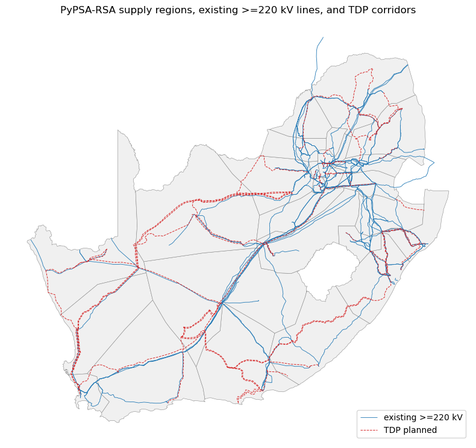

```python
import geopandas as gpd
import matplotlib.pyplot as plt

regions = gpd.read_file(AUDIT / 'za_rsa_supply_regions.geojson')
lines   = gpd.read_file(AUDIT / 'za_rsa_existing_lines_220kv_plus.geojson')
tdp     = gpd.read_file(AUDIT / 'za_rsa_planned_tdp_lines.geojson')

fig, ax = plt.subplots(1, 1, figsize=(8, 8))
regions.plot(ax=ax, color='#f0f0f0', edgecolor='#888', linewidth=0.4, label='supply regions')
lines.plot(ax=ax, color='#1f77b4', linewidth=0.6, label='existing >=220 kV')
tdp.plot(ax=ax, color='#d62728', linewidth=0.7, linestyle='--', label='TDP planned')
ax.set_title('PyPSA-RSA supply regions, existing >=220 kV lines, and TDP corridors')
ax.set_axis_off()
ax.legend(loc='lower right')
fig.tight_layout()
fig.savefig(FIG / 'grid_overview.png', dpi=160)
plt.show()
```

## 8 — Transmission expansion candidate evidence and resource siting

```python
te = pd.read_csv(AUDIT / 'pypsa_rsa_transmission_expansion_audit.csv')
rs = pd.read_csv(AUDIT / 'pypsa_rsa_resource_siting_audit.csv')
print('transmission expansion rows:', len(te))
print('resource siting rows:', len(rs))
rs
```

```
transmission expansion rows: 134
resource siting rows: 10
```

|  | rel_path | kind | description | present | feature_count | file_count | size_bytes | hash |
| --- | --- | --- | --- | --- | --- | --- | --- | --- |
| 0 | data/bundle/Power_corridors | directory | Power corridors | True | -1 | 7 | 1051449 | NaN |
| 1 | data/bundle/REDZ_DEA_Unpublished_Draft_2015 | directory | REDZ DEA unpublished draft | True | -1 | 8 | 922257 | NaN |
| 2 | data/bundle/Phase2_REDZs | directory | Phase 2 REDZs | True | -1 | 8 | 153615 | NaN |
| 3 | data/bundle/SAPAD_OR_2023_Q3.shp | shp | Protected areas (SAPAD) | True | 1655 | -1 | 7764848 | c42aa5bad52fa93070eea51ea35b900e821af9ec24b4e8... |
| 4 | data/bundle/SACAD_OR_2023_Q3.shp | shp | Conservation areas (SACAD) | True | 49 | -1 | 1674696 | 9bdf1af3f1fb68a6a44277111256db30b02d391f750c10... |
| 5 | data/bundle/SALandCover_OriginalUTM35North_201... | directory | Land cover raster set | True | -1 | 8 | 5310893522 | NaN |
| 6 | data/bundle/ZAF_wind-speed_100m.tif | raster | Wind speed @100m | True | -1 | -1 | 81105685 | 5932023031c50465db31727742526b5b200c13b84fbf7d... |
| 7 | data/bundle/ZAF15adjv4.tif | raster | Adjusted DEM | True | -1 | -1 | 0 | e3b0c44298fc1c149afbf4c8996fb92427ae41e4649b93... |
| 8 | data/bundle/Shapefiles/RE_IPP_1_to_4b.shp | shp | REIPPPP rounds 1-4b siting | True | 98 | -1 | 2844 | 92b643d6ba8f79b9dc5585451f76621e5c5282cc6c8b8c... |
| 9 | pre_processing/resource_processing | directory | PyPSA-RSA resource processing pre-pipeline | True | -1 | 17 | 6461087 | NaN |

## 9 — Acceptance gate self-check

Module 04 does not write fleet/carrier/cost/demand/grid overrides. The cells above demonstrate every required output exists with non-empty content. The supply-region layer resolution table identifies the 1/10/27/34/159 canonical layers, the Eskom pu profile audit is present, and `transmission_expansion` data is preserved as candidate evidence for module 13 — not consumed by the 2023 baseline.